# Reproducible Research: Peer Assessment 1

## Loading and preprocessing the data

```r
# First set working directory to location of "activity.csv"

# Load data
stepdata <- read.csv("activity.csv",header=TRUE)
```

## What is mean total number of steps taken per day?

Total number of steps per day

```r
library(dplyr)
groupbydate <- group_by(stepdata,date)
total.steps.per.day <- dplyr::summarise(groupbydate,sum(steps,na.rm=TRUE))
```

Histogram for total steps per day

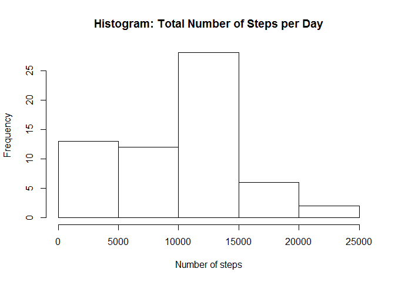

```r
hist(total.steps.per.day[[2]], main="Histogram: Total Number of Steps per Day",
        xlab="Number of steps")
```

Mean and Median total number of steps per day

```r
mean.steps.per.day <- mean(total.steps.per.day[[2]],na.rm=TRUE)
median.steps.per.day <- median(total.steps.per.day[[2]],na.rm=TRUE)
results <- cbind(mean.steps.per.day,median.steps.per.day)
names(results) <- c("Mean","Median")
```

## What is the average daily activity pattern?

Create time series plot for total steps by interval

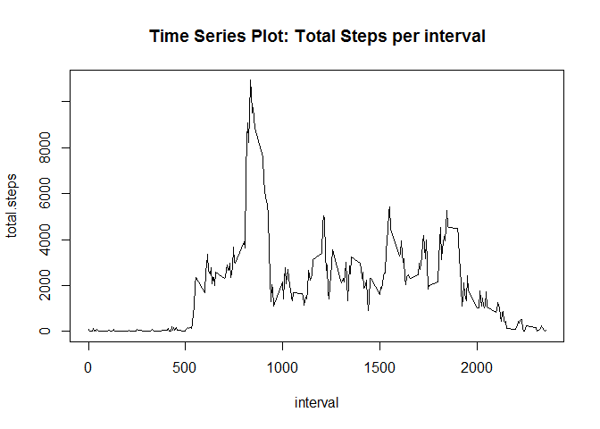

```r
group.by.interval <- group_by(stepdata,interval)
total.steps.by.int <- dplyr::summarise(group.by.interval,sum(steps,na.rm=TRUE))
names(total.steps.by.int)<-c("interval","total.steps")
with(total.steps.by.int,plot(y=total.steps,x=interval,type="l",
    main="Time Series Plot: Total Steps per interval"))
```

Interval with maximum number of total steps

```r
max.interval <- which(total.steps.by.int[[2]]==max(total.steps.by.int$total.steps))
interval <- total.steps.by.int[max.interval,][[1]]
max.step <- total.steps.by.int[max.interval,][[2]]
```

The maximum total steps is 10927 and occurs at interval 835.

## Imputing missing values

Count number of rows containing a missing value.

```r
total.missing <- sum(apply(stepdata, 1, function(x){any(is.na(x))}))
```

There are 2304 missing values.

Create new data set with imputed values for missing values

```r
# Get median for each interval and merge with original data set
med.step.by.int <- dplyr::summarise(group.by.interval,median(steps,na.rm=TRUE))
names(med.step.by.int) <- c("interval","median")
mergedStepData <- merge(stepdata,med.step.by.int)

# Copy merged data set into new data set that will contain the imputed values
imputeStepData <- mergedStepData

# Replace na values with the median for corresponding interval
na.steps <- is.na(imputeStepData$steps)
imputeStepData$steps[na.steps] <- imputeStepData$median[na.steps]

# Only want the variables relating to original data set
imputeStepData <- select(imputeStepData,steps,date,interval)
```

Make Histogram of total steps per day using imputed data set

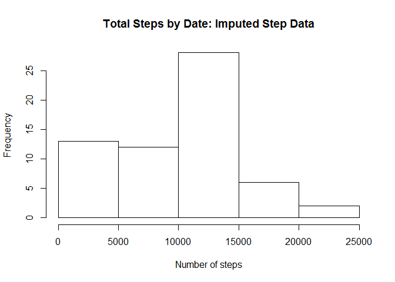

```r
impute.by.date <- group_by(imputeStepData,date)
impute.total.steps.by.date <- summarise(impute.by.date,sum(steps,na.rm=TRUE))
hist(impute.total.steps.by.date[[2]],main="Total Steps by Date: Imputed Step Data",
     xlab="Number of steps")
```

Mean and Median total number of steps per day for imputed data set

```r
imp.mean.steps.per.day <- mean(impute.total.steps.by.date[[2]],na.rm=TRUE)
imp.median.steps.per.day <- median(impute.total.steps.by.date[[2]],na.rm=TRUE)
imp.results <- cbind(round(imp.mean.steps.per.day), round(imp.median.steps.per.day))
names(imp.results) <- c("Mean","Median")
```

```r
rbind(round(results,1),round(imp.results,1))
```

```
##      mean.steps.per.day median.steps.per.day
## [1,]             9354.2                10395
## [2,]             9504.0                10395
```

## Are there differences in activity patterns between weekdays and weekends?

```r
# Create new column identifying if day is weekend or weekday
daytype <- weekdays(as.Date(imputeStepData$date))
daytype[daytype=="Saturday" | daytype=="Sunday"] <- "weekend"
daytype[!(daytype=="weekend")] <- "weekday"
imputeStepData$daytype <- daytype
```

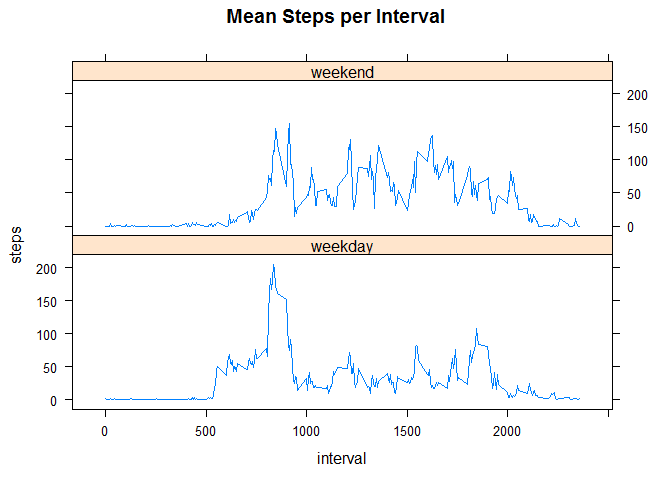

```r
# Create timeseries plot for mean steps per interval by weekend
library(lattice)
group.daytype.int <- group_by(imputeStepData, interval, daytype)
mean.steps.daytype.int <- summarize(group.daytype.int,mean(steps,na.rm=TRUE))
names(mean.steps.daytype.int) <- c("interval","daytype","steps")
xyplot(data=mean.steps.daytype.int, steps ~ interval | daytype, t="l",
       layout=c(1,2),main="Mean Steps per Interval")
```